# Part II - Ford GoBike System Data Exploration

## by Nathapon Tansit

## Investigation Overview

In this investigation, I focus on factors that effect on ride duration. I start by introducing ride duration distribution, followed by user type to see different distribution for each type. Then plot realtionship between ride duration and usage hour classified by user type in clustered bar chart.

## Dataset Overview

This data set includes information about 174952 individual rides(after remove rides that included any null values) made in a bike-sharing system covering the greater San Francisco Bay area in February 2019. Provided information for each ride are ride duration, start/edn time and location,user type,member birth year,ender,bike share for all trip.

## Distribution of Ride Duration

This plot shows distribution of ride duration from 0 to 75 minutes. Duration has a long-tailed distribution. Most of customers ride from 2 to 20 minutes. Peak at 5 minutes.

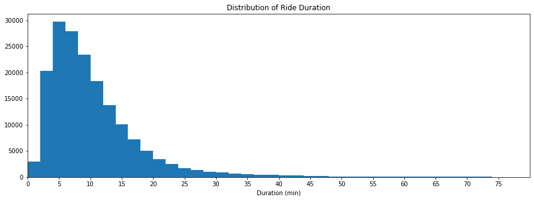

## Ride Duration vs. User types

This plot shows that casual customers ride longer than subscribers (13 > 8 mins compared by median). Ride duration of subscribers have less varient.

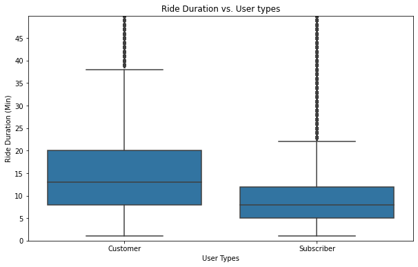

## Ride duration vs. Usage Hour Classified by user type

Casual customers always ride longer than subscribers. Ride duration of subscribers are very stable (less fluctuate) compared to casual customers. Surprisingly ride duration peak at 3.00.

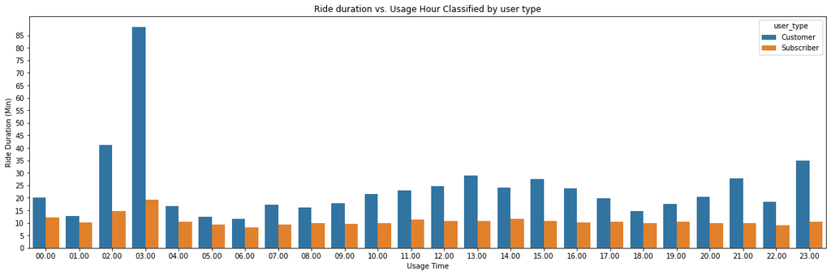